# CS 422 Section 01

Josh Bowden

**1.1.** By taking this course, I foremost hope to learn how to use machine learning to create models and make sense of larger datasets. I also hope to learn how to use R more since I do have some experience with the Python side of things. I’d also hope to get a better understanding of how to use fundamental statistics for understanding your data.

## Problem 1

**1-A**: Load the *cars* dataset and print it.

```r
data("cars")
cars
```

| speed | dist |
| --- | --- |
| 4 | 2 |
| 4 | 10 |
| 7 | 4 |
| 7 | 22 |
| 8 | 16 |
| 9 | 10 |
| 10 | 18 |
| 10 | 26 |
| 10 | 34 |
| 11 | 17 |

[output cut: 40 more lines]

**1-B**: Plot the data in the *cars* dataset. Provide a title for the graph. The title should be “The Cars Dataset”.

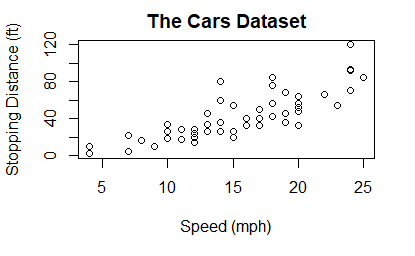

```r
plot(cars, main = "The Cars Dataset", xlab = "Speed (mph)", y = "Stopping Distance (ft)")
```

**1-C**: Print a summary of the cars dataset using the R `summary()` command.

```r
summary(cars)
```

```
     speed           dist
 Min.   : 4.0   Min.   :  2.00
 1st Qu.:12.0   1st Qu.: 26.00
 Median :15.0   Median : 36.00
 Mean   :15.4   Mean   : 42.98
 3rd Qu.:19.0   3rd Qu.: 56.00
 Max.   :25.0   Max.   :120.00
```

## Problem 2

**2-A**: Read the file into a data frame and add a new row consisting of the following data to the existing rows:

> name: Brad Pitt  
> id: 40051  
> gpa: 2.21  
> grade: C

Before adding the student:

```r
students <- read.csv("student.csv", sep=";", header=T)
students
```

| name | id | gpa | grade |
| --- | --- | --- | --- |
| Robert DeNiro | 9711 | 3.44 | B |
| Robert Downey, Jr | 33771 | 2.00 | C |
| Samantha Bee | 61094 | 4.00 | A |
| Jason Bateman | 45003 | 1.00 | E |
| Alicia Keyes | 55101 | 3.92 | B |
| Denzel Washington | 71005 | 4.00 | A |
| Joaquin Phoenix | 41180 | 2.89 | C |

After adding the new student:

```r
brad_pitt <- data.frame(name = "Brad Pitt",
                        id = 40051,
                        gpa = 2.21,
                        grade = "C")
students.new <- rbind(students, brad_pitt)
students.new
```

| name | id | gpa | grade |
| --- | --- | --- | --- |
| Robert DeNiro | 9711 | 3.44 | B |
| Robert Downey, Jr | 33771 | 2.00 | C |
| Samantha Bee | 61094 | 4.00 | A |
| Jason Bateman | 45003 | 1.00 | E |
| Alicia Keyes | 55101 | 3.92 | B |
| Denzel Washington | 71005 | 4.00 | A |
| Joaquin Phoenix | 41180 | 2.89 | C |
| Brad Pitt | 40051 | 2.21 | C |